# Practical Machine Learning - Course Project

Andreas Hermann

11/12/2018

## Executive summary

This report shows how a simple machine learning predictor can be built to do human activity recognition based on movement data. We try to predict the same 5 classes (sitting-down, standing-up, standing, walking, and sitting) with our own model.

We will address these main points:

- Model Building using Cross Validation
- Discussion of Sample Error
- Prediction of Test Cases

## Build Model

Load the data and do some exploratory analysis.

```r
training <- data.frame(read.csv2('pml-training.csv', sep = ',', dec = '.', na.strings = c('#DIV/0!', 'NA'), stringsAsFactors = TRUE))
testing <- data.frame(read.csv2('pml-testing.csv', sep = ',', dec = '.', na.strings = c('#DIV/0!', 'NA'), stringsAsFactors = TRUE))
```

Browse the data

```r
head(training)
```

```
##   X user_name raw_timestamp_part_1 raw_timestamp_part_2   cvtd_timestamp
## 1 1  carlitos           1323084231               788290 05/12/2011 11:23
## 2 2  carlitos           1323084231               808298 05/12/2011 11:23
## 3 3  carlitos           1323084231               820366 05/12/2011 11:23
## 4 4  carlitos           1323084232               120339 05/12/2011 11:23
## 5 5  carlitos           1323084232               196328 05/12/2011 11:23
## 6 6  carlitos           1323084232               304277 05/12/2011 11:23
##   new_window num_window roll_belt pitch_belt yaw_belt total_accel_belt
## 1         no         11      1.41       8.07    -94.4                3
## 2         no         11      1.41       8.07    -94.4                3
## 3         no         11      1.42       8.07    -94.4                3
## 4         no         12      1.48       8.05    -94.4                3
## 5         no         12      1.48       8.07    -94.4                3
## 6         no         12      1.45       8.06    -94.4                3
##   kurtosis_roll_belt kurtosis_picth_belt kurtosis_yaw_belt
```

[output cut: 265 more lines]

```r
str(training)
```

```
## 'data.frame':    19622 obs. of  160 variables:
##  $ X                       : int  1 2 3 4 5 6 7 8 9 10 ...
##  $ user_name               : Factor w/ 6 levels "adelmo","carlitos",..: 2 2 2 2 2 2 2 2 2 2 ...
##  $ raw_timestamp_part_1    : int  1323084231 1323084231 1323084231 1323084232 1323084232 1323084232 1323084232 1323084232 1323084232 1323084232 ...
##  $ raw_timestamp_part_2    : int  788290 808298 820366 120339 196328 304277 368296 440390 484323 484434 ...
##  $ cvtd_timestamp          : Factor w/ 20 levels "02/12/2011 13:32",..: 9 9 9 9 9 9 9 9 9 9 ...
##  $ new_window              : Factor w/ 2 levels "no","yes": 1 1 1 1 1 1 1 1 1 1 ...
##  $ num_window              : int  11 11 11 12 12 12 12 12 12 12 ...
##  $ roll_belt               : num  1.41 1.41 1.42 1.48 1.48 1.45 1.42 1.42 1.43 1.45 ...
##  $ pitch_belt              : num  8.07 8.07 8.07 8.05 8.07 8.06 8.09 8.13 8.16 8.17 ...
##  $ yaw_belt                : num  -94.4 -94.4 -94.4 -94.4 -94.4 -94.4 -94.4 -94.4 -94.4 -94.4 ...
##  $ total_accel_belt        : int  3 3 3 3 3 3 3 3 3 3 ...
##  $ kurtosis_roll_belt      : num  NA NA NA NA NA NA NA NA NA NA ...
##  $ kurtosis_picth_belt     : num  NA NA NA NA NA NA NA NA NA NA ...
##  $ kurtosis_yaw_belt       : logi  NA NA NA NA NA NA ...
```

[output cut: 86 more lines]

### Data Cleansing

Find the number of incomplete columns

```r
length(colnames(training)[colSums(is.na(training)) > 0])
```

```
## [1] 100
```

Remove columns containing NA values, as it is hard to predict the class for unknown values

```r
na.cols <- colnames(training)[apply(training, 2, anyNA)]
training[na.cols] <- NULL
```

Remove some columns that should not be used for the model

```r
training['X'] <- NULL
training['cvtd_timestamp'] <- NULL
training['user_name'] <- NULL
training['new_window'] <- NULL
```

Split the data into training and validation sets

```r
inTrain <- createDataPartition(training$classe, p=0.8, list=FALSE)
cv_train <- training[inTrain, ]
cv_validation <- training[-inTrain, ]
```

I will train two different types of models. Decision trees and random forests.

## Decision Trees

Train a decision tree with caret package rpart

```r
modFitRPart <- train(classe ~ ., data=cv_train, method="rpart")
```

Visualize the trained model

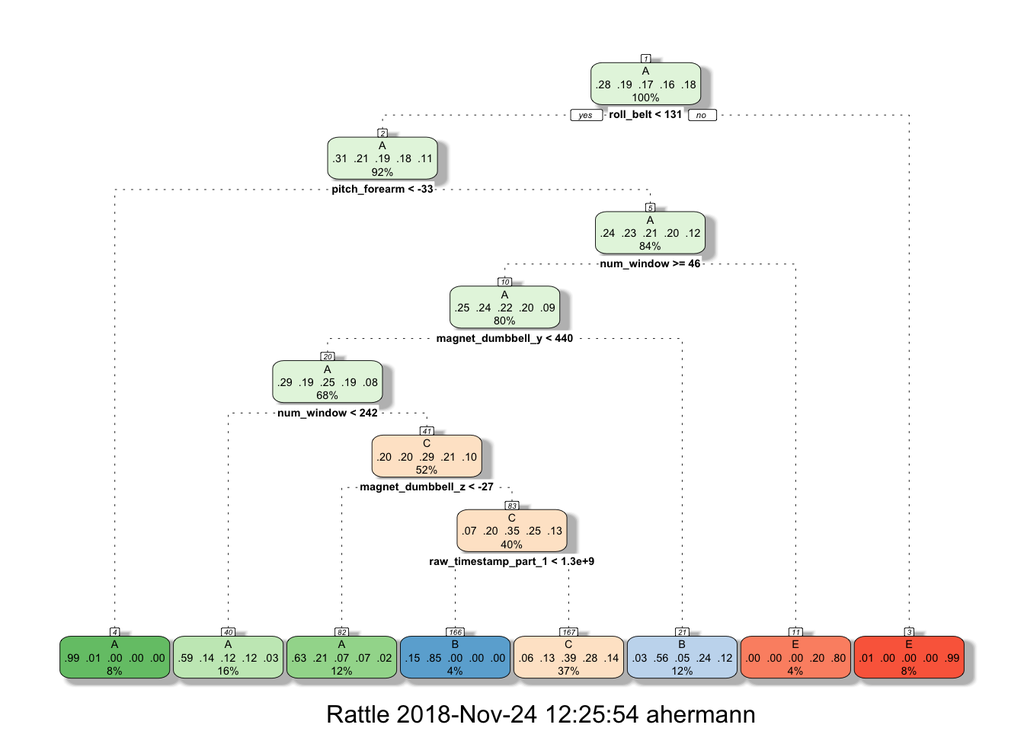

```r
fancyRpartPlot(modFitRPart$finalModel)
```

```r
pRF <- predict(modFitRPart, newdata=cv_validation)
confusionMatrix(cv_validation$classe, pRF)
```

```
## Confusion Matrix and Statistics
##
##           Reference
## Prediction   A   B   C   D   E
##          A 985  36  92   0   3
##          B 190 369 200   0   0
##          C  92  19 573   0   0
##          D 104 128 382   0  29
##          E  29  49 198   0 445
##
## Overall Statistics
##
##                Accuracy : 0.6046
##                  95% CI : (0.5891, 0.62)
##     No Information Rate : 0.3683
##     P-Value [Acc > NIR] : < 2.2e-16
##
##                   Kappa : 0.4946
##  Mcnemar's Test P-Value : < 2.2e-16
##
## Statistics by Class:
##
##                      Class: A Class: B Class: C Class: D Class: E
## Sensitivity            0.7036  0.61398   0.3965       NA   0.9329
## Specificity            0.9481  0.88260   0.9552   0.8361   0.9199
## Pos Pred Value         0.8826  0.48617   0.8377       NA   0.6172
## Neg Pred Value         0.8522  0.92668   0.7308       NA   0.9900
## Prevalence             0.3569  0.15320   0.3683   0.0000   0.1216
## Detection Rate         0.2511  0.09406   0.1461   0.0000   0.1134
## Detection Prevalence   0.2845  0.19347   0.1744   0.1639   0.1838
## Balanced Accuracy      0.8258  0.74829   0.6759       NA   0.9264
```

## Random Forests

Train a Random Forests model using 5-fold cross validation with the random forest method of caret package. Execute the code in parallel to speed up processing.

```r
cluster <- makeCluster(detectCores() - 1) # convention to leave 1 core for OS
registerDoParallel(cluster)

control <- trainControl(method = "cv", number = 5, allowParallel = TRUE)
modFitRF <- train(classe ~ ., data=cv_train, method="rf", trControl = control)

stopCluster(cluster)
```

Analyse the accuracy of the trained model.

```r
pRF <- predict(modFitRF, newdata=cv_validation)
confusionMatrix(cv_validation$classe, pRF)
```

```
## Confusion Matrix and Statistics
##
##           Reference
## Prediction    A    B    C    D    E
##          A 1116    0    0    0    0
##          B    1  758    0    0    0
##          C    0    1  683    0    0
##          D    0    0    0  642    1
##          E    0    0    0    0  721
##
## Overall Statistics
##
##                Accuracy : 0.9992
##                  95% CI : (0.9978, 0.9998)
##     No Information Rate : 0.2847
##     P-Value [Acc > NIR] : < 2.2e-16
##
##                   Kappa : 0.999
##  Mcnemar's Test P-Value : NA
##
## Statistics by Class:
##
##                      Class: A Class: B Class: C Class: D Class: E
## Sensitivity            0.9991   0.9987   1.0000   1.0000   0.9986
## Specificity            1.0000   0.9997   0.9997   0.9997   1.0000
## Pos Pred Value         1.0000   0.9987   0.9985   0.9984   1.0000
## Neg Pred Value         0.9996   0.9997   1.0000   1.0000   0.9997
## Prevalence             0.2847   0.1935   0.1741   0.1637   0.1840
## Detection Rate         0.2845   0.1932   0.1741   0.1637   0.1838
## Detection Prevalence   0.2845   0.1935   0.1744   0.1639   0.1838
## Balanced Accuracy      0.9996   0.9992   0.9998   0.9998   0.9993
```

## Prediction

Predict the class of the test data using our trained random forest model

```r
pRF <- predict(modFitRF, newdata=testing)
table(testing$X, pRF)
```

```
##     pRF
##      A B C D E
##   1  0 1 0 0 0
##   2  1 0 0 0 0
##   3  0 1 0 0 0
##   4  1 0 0 0 0
##   5  1 0 0 0 0
##   6  0 0 0 0 1
##   7  0 0 0 1 0
##   8  0 1 0 0 0
##   9  1 0 0 0 0
##   10 1 0 0 0 0
##   11 0 1 0 0 0
##   12 0 0 1 0 0
##   13 0 1 0 0 0
##   14 1 0 0 0 0
##   15 0 0 0 0 1
##   16 0 0 0 0 1
##   17 1 0 0 0 0
##   18 0 1 0 0 0
##   19 0 1 0 0 0
##   20 0 1 0 0 0
```